# Adaptive therapy simulations using OncoSimulR

Marta Lozano Prieto, Daniel Prieto Cebollero, Andrea Sánchez de la Cruz

2021-01-28. OncoSimulR version 2.99.7

# 1 Introduction

**Fitness** can be defined as the capacity of a subpopulation of organisms to successfully perpetuate itself in the next generation. Having said that, ***frequency-dependent fitness** refers to evolutionary phenomena where the fitness of a subpopulation depends on the frequency of other genotypes. Thus, frequency-dependent fitness needs to be considered in situations of commensalism, competition, parasitism, predation, mutualism… This is greatly related to what is called **“Evolutionary Game theory”** which, taking into account the costs and benefits of these multi-individual relationships, studies what their outcome may be. The subpopulation with the best interaction strategy will have the highest fitness, and thus it will be favoured under natural selection. However, this is a game in the sense that each organism’s fitness also depends on the strategies of the other subpopulations involved.

Moreover, the study of evolutionary dynamics can also be applied to contexts of therapy, considering the interactions between the malignant and normal cells. In a targeted entity (a group of bacteria, viruses, or malignant cells) there are multiple clones and subclones, with genetic differences, and their fitness will depend on their capacities, but also on the subclones’ interactions and competition for specific resources.

In classical therapy these small groups of cells are not considered and most of our antibiotics and cancer treatments focus on targeting as many cells as possible. For example, standard cancer treatment is based on a continuous use of maximum tolerated doses. In many cases, this is an appropriate solution. But in cases where cure cannot be found under classical terms, **adaptive therapy** can help patients to have a lower morbidity or mortality. In adaptive therapy the doses are administered based on the current state of tumour. The heterogeneity of the clones is considered in order to avoid situations where potential resistant clones take over the whole system once there is not a competition with the sensitive ones. As its name suggests, adaptive therapy is formed of several successive cycles where the clones and subclones are controlled in a loop.

In order to understand how this therapy worked, we as a group started using `OncoSimulR` package to simulate a general situation of adaptive therapy. Next, we looked through literature, and simulated two specific examples of adaptive therapy. The first one, which is based on *Melnikov et al. (2020)*, is a simulation of the dynamics within a bacterial population. On the contrary, the second example that we chose, which is described in *West et al. (2020)*, was used to model the dynamics of different cell types present in a case of resistant prostate cancer.

## 1.1 Simulating adaptive therapy: steps

This first simulation is a general, rather theoretical one. In this case, as this example is the simplest possible, two cell populations were established: one **sensitive (S)** and one **resistant (R)** to the therapy.

The fitness equation of the sensitive population will only take into account a negative factor **cS** that refers to the cohabit cost. Since the space and resources are shared by both subpopulations, it is dependent on their density. The equation of the resistant population is very similar, but it also considers that their fitness is negatively affected by the fact that they are resistant; in other words, there is a resistance cost, here referred to as **cR**.

The **fitness equations** are the following:

$$\begin{align}
W\left(S\right) = 1 - cS·\left(f_S + f_R\right)\\
W\left(R\right) = 1 - cS·\left(f_S + f_R\right) - cR\\
\end{align}$$

1. A dataframe with the different genotypes and their fitness equations was generated.
2. `allFitnessEffects` function was launched, which establishes the frequency dependent fitness. In the three simulations we used relative frequencies.
3. The model can be generated using the fitness values from `allFitnessEffect` function at each time running `oncoSimulIndiv`. The McFarland probabilistic model was used in the three simulations.

```r
cS <- 0.2 # cohabit cost
cR <- 0.1 # resistance cost

# Fitness equations
S_fitness <- paste0("1 - ", cS, " * (f_S + f_R)")
R_fitness <- paste0("1 - ", cS, " * (f_S + f_R) - ", cR)

drug <- 0.01 # drug effect
```

**STANDARD TARGETED THERAPY:** *treatment for cure*

```r
# Define fitness of the genotypes
std_df <- function(cS, cR, gt = c("WT", "S", "R")) {
  data.frame(Genotype = gt,
             Fitness = c("1",
                         paste0("if (T > 20) ", drug, "*(", S_fitness, ")",";
                                else ", S_fitness, ";"),
                         R_fitness),
             stringsAsFactors = FALSE)
}
# Fitness effects specification
std_eff <- allFitnessEffects(genotFitness = std_df(cS, cR),
                             frequencyDependentFitness = TRUE,
                             frequencyType = "rel")

set.seed(1) # for reproducibility
std_simul <- oncoSimulIndiv(std_eff,
                            model = "McFL",
                            onlyCancer = FALSE,
                            mu = 0.01,
                            finalTime = 80,
                            initSize = c(WT=1,S=500, R=500),
                            seed = NULL,
                            initMutant = c("WT", "S", "R"))
```

```
## Init Mutant with birth == 1.0
```

**ADAPTIVE THERAPY:** *treatment for contain*

```r
# Define fitness of the genotypes
adapt_df <- function(cS, cR, gt = c("WT", "S", "R")) {
  data.frame(Genotype = gt,
             Fitness = c("1",
                         paste0("if ((((T > 15) & (T < 18)) |
                                      ((T > 38) & (T < 41)) |
                                      ((T > 61) & (T < 64)))) ",
                                drug, "*(", S_fitness, ")",";
                                else ", S_fitness, ";"),
                         R_fitness),
             stringsAsFactors = FALSE)
}
# Fitness effects specification
adapt_eff <- allFitnessEffects(genotFitness = adapt_df(cS, cR),
                               frequencyDependentFitness = TRUE,
                               frequencyType = "rel")

set.seed(1) # for reproducibility
adapt_simul <- oncoSimulIndiv(adapt_eff,
                              model = "McFL",
                              onlyCancer = FALSE,
                              mu = 0.01,
                              finalTime = 80,
                              initSize = c(WT=1,S=500, R=500),
                              seed = NULL,
                              initMutant = c("WT", "S", "R"))
```

```
## Init Mutant with birth == 1.0
```

The results were represented as graphics for interpretation. The first plot represents the result of the “standard therapy”. Importantly, the constant use of the drug drastically reduces the sensitive cells fitness, consequently freeing the resistant cells from their competition, which allows their uncontrolled growth. This is why in this case adaptive therapy is a better approach. It is represented in second plot, where the successive therapy cycles allow a more controlled management of both cell subpopulations growth.

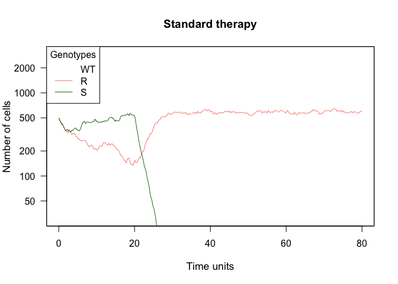

```r
# Plot representation
plot(std_simul, show = "genotypes", type = "line",
     thinData = TRUE, col = c("white", "salmon", "darkgreen"),
     ylim = c(30, 3000), las = 1,
     cex.lab=1.1, main = "Standard therapy")
```

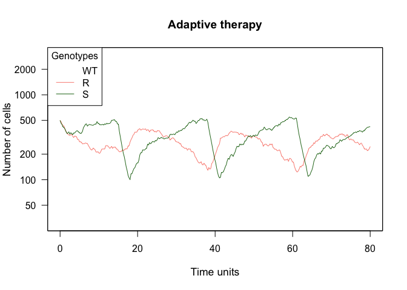

```r
plot(adapt_simul, show = "genotypes", type = "line",
     thinData = TRUE, col = c("white", "salmon", "darkgreen"),
     ylim = c(30, 3000), las = 1,
     cex.lab=1.1, main = "Adaptive therapy")
```

# 2 Management of drug resistant populations in bacteria

This example is based on *Melnikov et al. (2020)*. There are 3 phenotypic groups: **tavaborole-sensitive bacteria (WT)**, **tavaborole-resistant bacteria (EcoR)** and **multidrug-resistant bacteria (EcoMR)**.

A cohabit cost (**cS**) is considered, since WT, EcoR and EcoMR compete for resources. In addition, we assume that EcoR and EcoMR have an additional resistance cost (**cR** and **cMR**, respectively) due to the fact that antibiotic resistance can cause growth defects that alter the fitness of resistant populations.

```r
cS <- 0.2 # cohabit cost
cR <- 0.1 # resistance cost of EcoR
cMR <- 0.4 # resistance cost of EcoMR

# Fitness equations
WT_fitness <- paste0("1 - ", cS, " * (f_ + f_EcoR + f_EcoMR)")
EcoR_fitness <- paste0("1 - ", cS, " * (f_ + f_EcoR + f_EcoMR) - ", cR)
EcoMR_fitness <- paste0("1 - ", cS, " * (f_ + f_EcoR + f_EcoMR) - ", cMR)

# Drug effects
tavab <- 0.1 # tavaborole
norvaline <- 0.7 # norvaline
```

We establish fitness as:

$$\begin{align}
W\left(WT\right) = 1 - cS·\left(f_{WT} + f_{EcoR} + f_{EcoMR}\right)\\
W\left(EcoR\right) = 1 - cS·\left(f_{WT} + f_{EcoR} + f_{EcoMR}\right) - cR\\
W\left(EcoMR\right) = 1 - cS·\left(f_{WT} + f_{EcoR} + f_{EcoMR}\right) - cMR\\
\end{align}$$

We simulate two scenarios using two drugs (tavaborole and norvaline): **simultaneous standard therapy** and **adaptive therapy**. We add the effect of **tavaborole** and **norvaline** as a fixed coefficient (tavab and norvaline). The fitness of the three populations depends on time and on the effect of both drugs: tavaborole just alters WT population fitness, since the rest of strains are resistant. However, since resistance to tavaborole confers hypersensitivity to norvaline in the EcoR strain, we assume in this model that EcoR is 3 times more sensitive to norvaline than the WT strain.

## 2.1 Scenario with simultaneous therapy (tavaborole + norvaline)

When starting the simulation, just tavaborole is initially applied. After a certain period of time, norvaline is added.

```r
# Define fitness of the genotypes
eco_df_std <- function(cS, cR, cMR, gt = c("WT", "EcoR", "EcoMR")) {
  data.frame(Genotype = gt,
             Fitness = c(paste0("if (T > 10) ",
                                tavab, "*(", WT_fitness, ")",";
                                else if (T > 17) ",
                                norvaline, "*(", WT_fitness, ")",";
                                else ", WT_fitness, ";"),
                         paste0("if (T > 17) ",
                                norvaline/3, "*(", EcoR_fitness, ")",";
                                else ", EcoR_fitness, ";"),
                         EcoMR_fitness),
             stringsAsFactors = FALSE)
}

# Fitness effects specification
eco_eff_std <- allFitnessEffects(genotFitness = eco_df_std(cS, cR, cMR),
                                 frequencyDependentFitness = TRUE,
                                 frequencyType = "rel")

set.seed(4) # for reproducibility
eco_simul_std <- oncoSimulIndiv(eco_eff_std,
                                model = "McFL",
                                onlyCancer = FALSE,
                                mu = 0.01,
                                initSize = 500,
                                finalTime = 60,
                                seed = NULL)
```

## 2.2 Scenario with adaptive therapy

In this case EcoMR fitness is very low, since WT and EcoR strains are not exposed to that high selective pressure (2 drugs at the same time). Here, the fixed dosages of tavaborole and norvaline are applied consecutively, alternating with drug-free periods.

```r
# Define fitness of the genotypes
eco_df_adapt <- function(cS, cR, cMR, gt = c("WT", "EcoR", "EcoMR")) {
  data.frame(Genotype = gt,
             Fitness = c(paste0("if (((T > 10) & (T < 16)) | (T > 50))",
                                tavab, "*(", WT_fitness, ")",";
                                else if ((T > 35) & (T < 45))",
                                norvaline, "*(", WT_fitness, ")", ";
                                else ", WT_fitness, ";"),
                         paste0("if ((T > 35) & (T < 45)) ",
                                norvaline/3, "*(", EcoR_fitness, ")",";
                                else ", EcoR_fitness, ";"),
                         paste0(0.05, "*(", EcoMR_fitness, ")")),
             stringsAsFactors = FALSE)
}
# Fitness effects specification
eco_eff_adapt <- allFitnessEffects(genotFitness = eco_df_adapt(cS, cR, cMR),
                                   frequencyDependentFitness = TRUE,
                                   frequencyType = "rel")

set.seed(4) # for reproducibility
eco_simul_adapt <- oncoSimulIndiv(eco_eff_adapt,
                                  model = "McFL",
                                  onlyCancer = FALSE,
                                  mu = 0.01,
                                  finalTime = 60,
                                  initSize = 500,
                                  seed = NULL)
```

## 2.3 Standard vs. adaptive therapy

Whereas in standard therapy WT and EcoR populations disappear, leaving the emergent multidrug-resistant bacteria proliferate, in adaptive therapy sensitive and resistant bacteria coexist during the treatment in an equilibrium.

The comparison of both approaches proves that shorter and non-simultaneous treatment (adaptive therapy) is beneficial to control resistant populations and to avoid multidrug-resistance evolution.

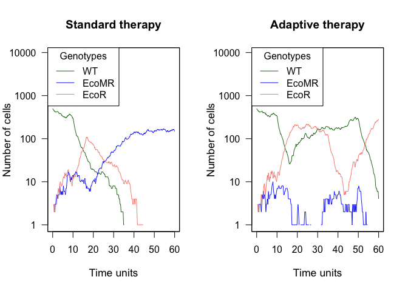

```r
# Plot representation
op <- par(mfrow = c(1, 2))

plot(eco_simul_std, show = "genotypes", type = "line",
     thinData = TRUE, col = c("darkgreen", "blue", "salmon"),
     las = 1, ylim = c(1, 9000),
     cex.lab=1.1, main = "Standard therapy")

plot(eco_simul_adapt, show = "genotypes", type = "line",
     thinData = TRUE, col = c("darkgreen", "blue", "salmon"),
     las = 1, ylim = c(1, 9000),
     cex.lab=1.1, main = "Adaptive therapy")
```

# 3 Adaptive therapy in resistant prostate cancer

This example is based on *West et al. (2020)*. It describes a case of standard vs adaptive therapy applied to three types of cells of terminal prostate cancer.

Within the prostate tumour there is a variety of subpopulations, each one with different resistance profiles to androgen deprivation therapy. These three populations are defined as **wild type or testosterone sensitive (WT)**, **testosterone producing (TP)** and **testosterone resistant (TR)** tumour cells. Both the fitness of the WT and TP are positively affected by the testosterone produced by the TP, which is modelled by introducing a benefit factor hereafter referred to as **bT**. Several negative factors were also included in the equations. TP cells fitness is negatively affected by the cost of producing testosterone (**cT**), while TR cells fitness is reduced by the influence of a resistance cost (**cR**). Lastly, the three cell types are influenced by a cohabit cost factor (**cS**). The benefit of systemic testosterone was not added to the equation as it will be a therapy target later in this example. The capacity of TP cells to support WT cells was adjusted in order to reflect the proportions stated in the article.

Fitness equations were described as follows:

$$\begin{align}
W\left(WT\right) = 1 + bT·\left(f_{TP}\right) - cS·\left(f_{WT} + f_{TP} + f_{TR}\right)\\
W\left(TP\right) = 1 + bT·\left(f_{TP}\right) - cS·\left(f_{WT} + f_{TP} + f_{TR}\right) - cT\\
W\left(TR\right) = 1 - cS·\left(f_{WT} + f_{TP} + f_{TR}\right) - cR\\
\end{align}$$

```r
bT <- 0.7 # benefit of TP producing testosterone
cS <- 0.2 # cohabit cost
cT <- 0.3 # testosterone production cost
cR <- 0.3 # resistance cost

# Fitness equations
WT_fitness <- paste0("1 + ", bT, " * (f_TP) - ", cS, " * (f_ + f_TP + f_TR)")
TP_fitness <- paste0("1 + ", bT, " * (f_TP) - ", cS, " * (f_ + f_TP + f_TR) - ", cT)
TR_fitness <- paste0("1 - ", cS, " * (f_ + f_TP + f_TR) - ", cR)
```

## 3.1 Scenario without treatment

Firstly, aiming to the analysis of the interactions of all the cell types, an initial simulation without any treatment and starting with the same population size of each cell type was performed. Results are shown in the graph below, where noticeably **most of the cells are WT**. The other cell populations are stable in reduced numbers.

```r
# Define fitness of the genotypes
prost_df <- function(bT, cS, cT, cR, gt = c("WT", "TP", "TR")) {
  data.frame(Genotype = gt,
             Fitness = c(WT_fitness,
                         TP_fitness,
                         TR_fitness),
             stringsAsFactors = FALSE)
}

# Fitness effects specification
prost_eff <- allFitnessEffects(genotFitness = prost_df(bT, cS, cT, cR),
                               frequencyDependentFitness = TRUE,
                               frequencyType = "rel")

set.seed(4) # for reproducibility
prost_simul <- oncoSimulIndiv(prost_eff,
                              model = "McFL",
                              onlyCancer = FALSE,
                              mu = 0.01,
                              finalTime = 100,
                              initSize = c(WT=500, TP=500, TR=500),
                              seed = NULL,
                              initMutant = c("WT", "TP", "TR"))
```

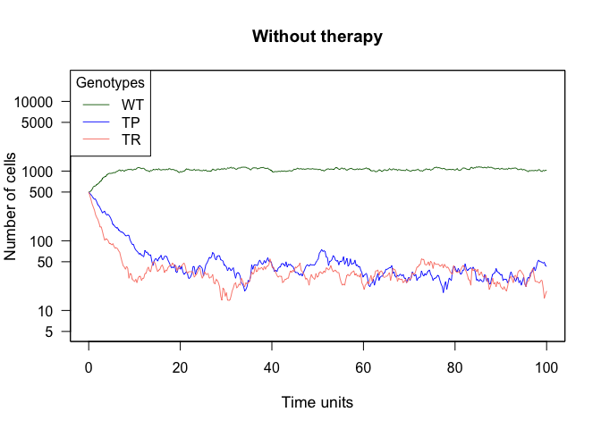

```r
# Plot representation
plot(prost_simul, show = "genotypes", type = "line",
     thinData = TRUE, col = c("darkgreen", "blue", "salmon"),
     ylim = c(5, 20000), las = 1,
     cex.lab=1.1, main = "Without therapy")
```

## 3.2 Adaptive therapy scenario

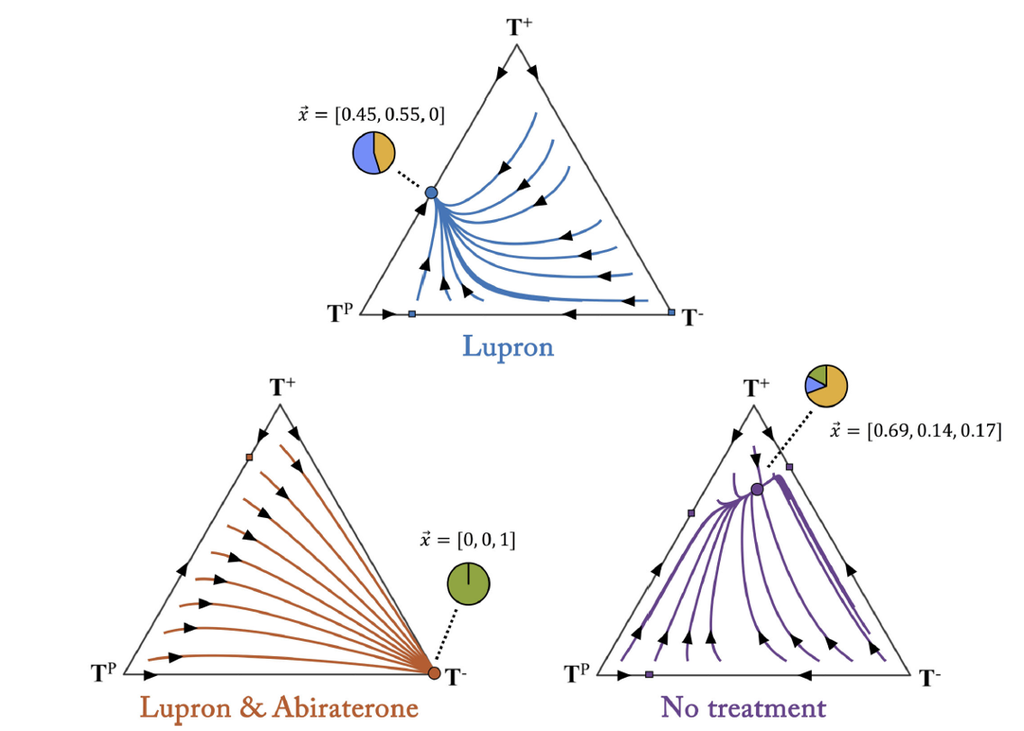

Figure 3.1: West et al. (2020). Temporal dynamics under therapy.

Next, the adaptive therapy scenario was simulated. This strategy is represented in the graph below, where the **effects of one single treatment cycle** are shown. Each cycle is composed of three consecutive phases: lupron treatment, no-treatment and simultaneous treatment with lupron and abiraterone. Starting from a baseline condition, **lupron treatment** effect was included in the model from time unit 20 to 70. Since lupron inhibits the systemic testosterone production, during this period WT cells fitness is dramatically reduced as they require testosterone for growth. However, since TP cells produce testosterone by their own, they are favoured under this condition, which at the same time implies a competition increase against TR cells, fitness of which decreases. Then, a **short drug-free period** (during 3 time units) partially reverses the latter effects. Finally, the **combination of Lupron and abiraterone** (from time unit 73) favours the testosterone independent (TR) population, as both systemic and TP produced testosterone sources are inhibited.

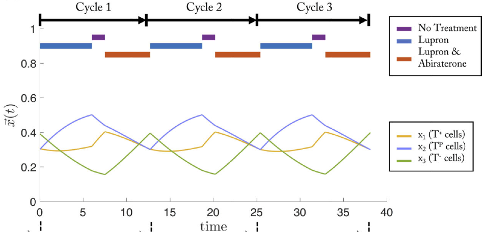

Figure 3.2: West et al. (2020). Sequential treatments which lead to an evolutionary cycle.

These treatment phases can be repeated, controlling the tumour in cycles. By the appropriate treatment “switching”, these three cell types remain in competition with each other, avoiding the emergence of resistance.

```r
# Drug effects
lupron_eff <- 0.6
abir_eff <- 0.8

# Define fitness of the genotypes
prost_2drugs <- function(bT, cS, cT, cR, gt = c("WT", "TP", "TR")) {
  data.frame(Genotype = gt,
             Fitness = c(paste0("if ((T > 20) & (T < 70)) ", lupron_eff,
                                "*(", WT_fitness, ")",";
                                else if ((T > 73) & (T < 210)) ", lupron_eff,
                                "*(", WT_fitness, ")", ";
                                else ", WT_fitness, ";"),
                         paste0("if ((T > 20) & (T < 70)) ", lupron_eff*1.5,
                                "*(", TP_fitness, ")",";
                                else if ((T > 73) & (T < 210))",
                                abir_eff*lupron_eff*1.5, "*(", TP_fitness, ")", ";
                                else ", TP_fitness, ";"),
                         TR_fitness),
             stringsAsFactors = FALSE)
}

# Fitness effects specification
prost_eff <- allFitnessEffects(genotFitness = prost_2drugs(bT, cS, cT, cR),
                               frequencyDependentFitness = TRUE,
                               frequencyType = "rel")

set.seed(4) # for reproducibility
prost_simul <- oncoSimulIndiv(prost_eff, model = "McFL",
                              onlyCancer = FALSE,
                              mu = 0.01,
                              finalTime = 210,
                              initSize = c(WT=500, TP=500, TR=500),
                              seed = NULL,
                              initMutant = c("WT", "TP", "TR"))
```

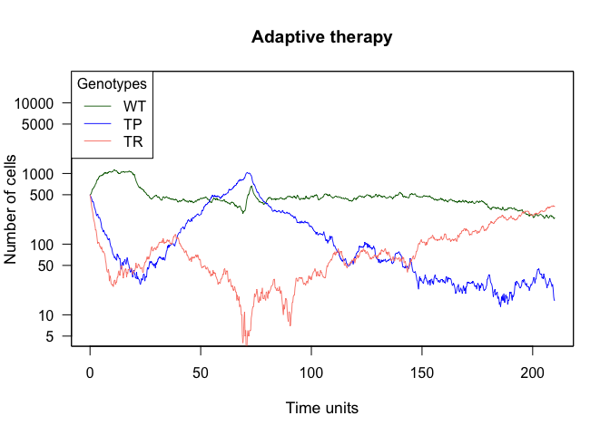

```r
# Plot representation
plot(prost_simul, show = "genotypes", type = "line",
     thinData = TRUE, col = c("darkgreen", "blue", "salmon"),
     ylim = c(5, 20000), las = 1,
     cex.lab=1.1, main = "Adaptive therapy")
```

# 4 OncoSimulR limitations

1. It would be interesting to be able to adjust the therapy intervals by a biomarker level (**Prostate Specific Antigen** in the case of *West et al. 2020*) apart from using time (T) or population size (N) in order to optimize the treatment of a tumor. We could not find a way to simulate the production levels of this biomarker.
2. When establishing just 2 populations in the model the function `allFitnessEffects` yields an error: *dim(X) must have a positive length*

```r
cS <- 0.2 # cohabit cost
cR <- 0.1 # resistance cost

# Fitness equations
S_fitness <- paste0("1 - ", cS, " * (f_S + f_R)")
R_fitness <- paste0("1 - ", cS, " * (f_S + f_R) - ", cR)

drug <- 0.01 # drug effect

# Define fitness of the genotypes
std_df <- function(cS, cR, gt = c("WT", "R")) {
  data.frame(Genotype = gt,
             Fitness = c(paste0("if (T > 20) ", drug, "*(", S_fitness, ")",";
                                else ", S_fitness, ";"),
                         R_fitness),
             stringsAsFactors = FALSE)
}
# Fitness effects specification
# std_eff <- allFitnessEffects(genotFitness = std_df(cS, cR),
#                             frequencyDependentFitness = TRUE,
#                             frequencyType = "rel")

# Error in apply(m[, 1:length(all_genes)], 2, as.numeric) : dim(X) must have a positive length
```

# 5 References

1. Melnikov, S. V., Stevens, D. L., Fu, X., Kwok, H. S., Zhang, J.-T., Shen, Y., Sabina, J., Lee, K., Lee, H., & Söll, D. (2020). Exploiting evolutionary trade-offs for posttreatment management of drug-resistant populations. Proceedings of the National Academy of Sciences, 117(30), 17924–17931. https://doi.org/10.1073/pnas.2003132117
2. West J., You L., Zhang J., Gatenby R. A., Brown J. S., Newton P. K., Anderson A. R. A. (2020). Towards Multidrug Adaptive Therapy. Cancer Research, 80(7), 1578-1589. https://doi.org/10.1158/0008-5472.CAN-19-2669